# Course Project 2 - NOAA Storm Data

bthomas

February 13, 2016

# Instructions

## Introduction

Storms and other severe weather events can cause both public health and economic problems for communities and municipalities. Many severe events can result in fatalities, injuries, and property damage, and preventing such outcomes to the extent possible is a key concern.

This project involves exploring the U.S. National Oceanic and Atmospheric Administration’s (NOAA) storm database. This database tracks characteristics of major storms and weather events in the United States, including when and where they occur, as well as estimates of any fatalities, injuries, and property damage.

## Synopsis

Storm data was evaluated based on the recorded events. Tornados lead the other categories in injury and fatalities. The category Flood leads all other for economic damange.

## Data Processing

The data for this assignment come in the form of a comma-separated-value file compressed via the bzip2 algorithm to reduce its size. The file can be retrieved from the course web site:

```
[Storm Data [47Mb]](https://d396qusza40orc.cloudfront.net/repdata%2Fdata%2FStormData.csv.bz2)
```

Database documentation is available through the 2 links below. The documents below will provide information on variable construction and definition.

```
[National Weather Service Storm Data Documentation](https://d396qusza40orc.cloudfront.net/repdata%2Fpeer2_doc%2Fpd01016005curr.pdf)
[National Climatic Data Center Storm Events FAQ](https://d396qusza40orc.cloudfront.net/repdata%2Fpeer2_doc%2FNCDC%20Storm%20Events-FAQ%20Page.pdf)
```

The events in the database start in the year 1950 and end in November 2011. In the earlier years of the database there are generally fewer events recorded, most likely due to a lack of good records. More recent years should be considered more complete.

The code below was used to download the Storm Data to a data directory. It sets the working directory, cleans up the Global Environment, checks to see if the compressed data file was downloaded, downloads it if it has not been, checks for the unzipped file, checks to determine if it was not extracted, and it has not, it extracts the data file.

```r
# clean the global environment
rm(list = ls())
# set the working directory to the Course-Project-1 director
setwd("~/Documents/Coursera/Reproducable-Research/Course-Project-2")

# check to see if the file has been downloaded, if not, download the file
if (!file.exists("./Data/repdata_data_StormData.csv.bz2")) {
  download.file("https://d396qusza40orc.cloudfront.net/repdata%2Fdata%2FStormData.csv.bz2", "./Data/repdata_data_StormData.csv.bz2", method = "curl")

}

# check to see if the archives.csv exists, if not, extract it
if (!file.exists("./Data/repdata_data_StormData.csv")) {
  unzip("./Data/repdata_data_StormData.csv.bz2", exdir = "./Data/")

}
```

```
Data Processing Warning in unzip("./Data/repdata_data_StormData.csv.bz2", exdir = "./
Data Processing Data/"): error 1 in extracting from zip file
```

The storm event categories were kept as entered. Other researchers, may wish to generalize the categories. For example, Flood, Flash Flood, and River Flood are separate categorizes. Without a better understanding of the semantic needs, this paper choose to keep all categories as entered.

# 2.0 Research Quesitons

## 2.1 Across the United States, which types of events (as indicated in the EVTYPE variable) are most harmful with respect to population health?

For this research question, harm to health was viewed as causing death or injury.

```r
# Set the working directory to the course project directory
setwd("~/Documents/Coursera/Reproducable-Research/Course-Project-2")
stormActivity <- read.csv("./Data/repdata_data_StormData.csv.bz2")
library(dplyr)
```

```r
library(ggplot2)
# use only rows that have greater than 0 for injuries or fatalities
sa <- subset(select(stormActivity, EVTYPE, FATALITIES:PROPDMGEXP), FATALITIES > 0 | INJURIES > 0)

# top 10 fatalities causes
storm_fatalities <- aggregate(FATALITIES ~ EVTYPE, data = sa, sum)
storm_fatalities <- storm_fatalities[order(-storm_fatalities$FATALITIES), ][1:10, ]
head(storm_fatalities)
```

```
Question 2.1             EVTYPE FATALITIES
Question 2.1 184        TORNADO       5633
Question 2.1 32  EXCESSIVE HEAT       1903
Question 2.1 42     FLASH FLOOD        978
Question 2.1 69            HEAT        937
Question 2.1 122      LIGHTNING        816
Question 2.1 191      TSTM WIND        504
```

```r
# top 10 fatality causes
storm_injuries <- aggregate(INJURIES ~ EVTYPE, data = sa, sum)
storm_injuries <- storm_injuries[order(-storm_injuries$INJURIES),][1:10,]
head(storm_injuries)
```

```
Question 2.1             EVTYPE INJURIES
Question 2.1 184        TORNADO    91346
Question 2.1 191      TSTM WIND     6957
Question 2.1 47           FLOOD     6789
Question 2.1 32  EXCESSIVE HEAT     6525
Question 2.1 122      LIGHTNING     5230
Question 2.1 69            HEAT     2100
```

The top 10 fatality caues are listed above. The Torando category leads other categories in injury and fatalities.

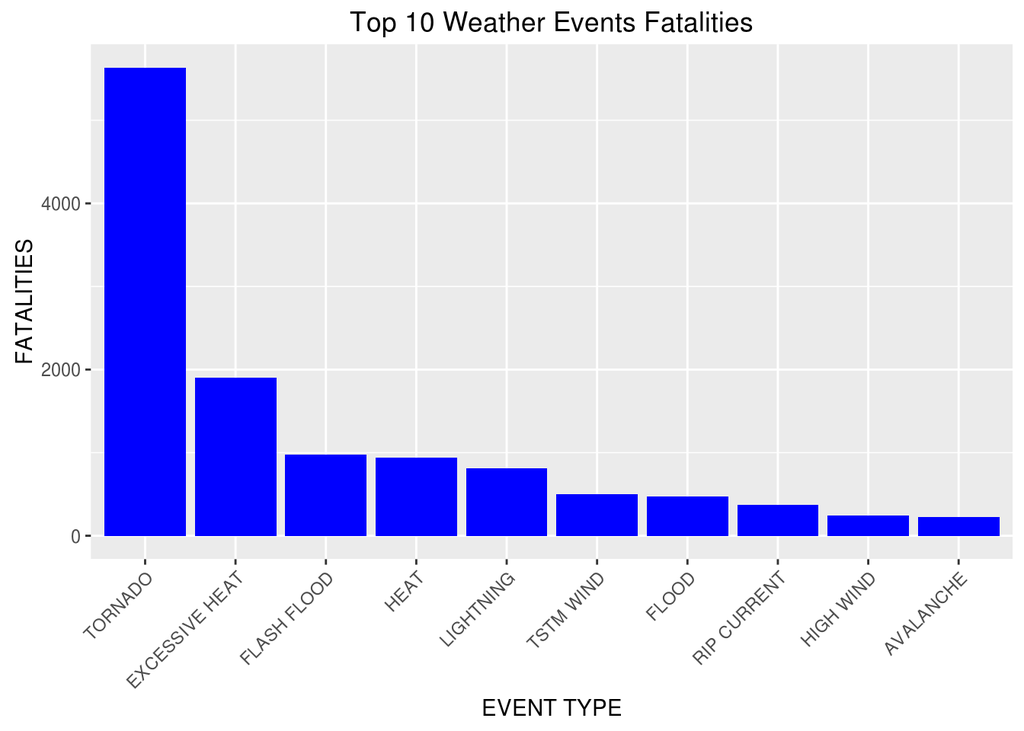

```r
# uses factors to determine order
storm_fatalities$EVTYPE <- factor(storm_fatalities$EVTYPE, levels = storm_fatalities$EVTYPE)
ggplot(storm_fatalities, aes(x = EVTYPE, y = FATALITIES)) +
  geom_bar(stat = "identity", fill = "blue") +
  theme(axis.text.x = element_text(angle = 45, hjust = 1)) +
  xlab("EVENT TYPE") + ylab("FATALITIES") +
  ggtitle("Top 10 Weather Events Fatalities")
```

```r
head(storm_injuries)
```

```
##             EVTYPE INJURIES
## 184        TORNADO    91346
## 191      TSTM WIND     6957
## 47           FLOOD     6789
## 32  EXCESSIVE HEAT     6525
## 122      LIGHTNING     5230
## 69            HEAT     2100
```

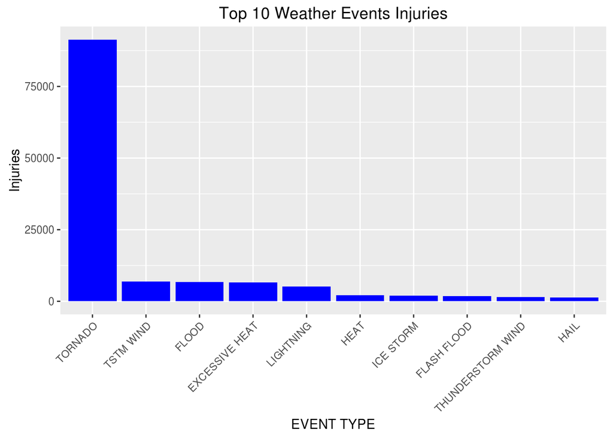

```r
storm_injuries$EVTYPE <- factor(storm_injuries$EVTYPE, levels = storm_injuries$EVTYPE)
ggplot(storm_injuries, aes(x = EVTYPE, y = INJURIES)) +
  geom_bar(stat = "identity", fill = "blue") +
  theme(axis.text.x = element_text(angle = 45, hjust = 1)) +
  xlab("EVENT TYPE") + ylab("Injuries") +
  ggtitle("Top 10 Weather Events Injuries")
```

## 2.2 Across the United States, which types of events have the greatest economic consequences?

Para 2.7 of the NWS Storm Documentation states that “K” for thousands, “M” for millions, and “B” for billions“. Using their guidelines a tranform was by mapping numeric values for the alpha codes multipled by the units. The category flood leads the economic impact against the other categories.

```r
dollar_damages <- select(stormActivity, EVTYPE, PROPDMG:CROPDMGEXP)

dollar_damages$PROPDMGEXP <-toupper(dollar_damages$PROPDMGEXP)
dollar_damages$CROPDMGEXP <- toupper(dollar_damages$CROPDMGEXP)

# factorize the new event column
# dollar_damages$EVTYPE1<- factor(dollar_damages$EVTYPE)

dollar_damages<- mutate(dollar_damages,PROPUNIT= 0, CROPUNIT=0)
ind<- grep("h|H", dollar_damages$PROPDMGEXP)
dollar_damages$PROPUNIT[ind]=100
ind<- grep("k|K", dollar_damages$PROPDMGEXP)
dollar_damages$PROPUNIT[ind]=1000
ind<- grep("m|M", dollar_damages$PROPDMGEXP)
dollar_damages$PROPUNIT[ind]=1e6
ind<- grep("b|B", dollar_damages$PROPDMGEXP)
dollar_damages$PROPUNIT[ind]=1e9

ind<- grep("h|H", dollar_damages$CROPDMGEXP)
dollar_damages$CROPUNIT[ind]=100
ind<- grep("k|K", dollar_damages$CROPDMGEXP)
dollar_damages$CROPUNIT[ind]=1000
ind<- grep("m|M", dollar_damages$CROPDMGEXP)
dollar_damages$CROPUNIT[ind]=1e6
ind<- grep("b|B", dollar_damages$CROPDMGEXP)
dollar_damages$CROPUNIT[ind]=1e9

# Calculate $ damages
propDamage<- dollar_damages %>%
  select(EVTYPE,PROPDMG,PROPDMGEXP,CROPDMG,CROPDMGEXP,PROPUNIT,CROPUNIT) %>%
  group_by(EVTYPE) %>%
  # summarize numbers to millions
  summarise(TotalProp= sum(PROPDMG*PROPUNIT)/1e6,
            TotalCrop= sum(CROPDMG*CROPUNIT)/1e6,
            TotalDmg= TotalProp+TotalCrop) %>%
  arrange(desc(TotalDmg), desc(TotalProp), desc(TotalCrop))

#top 10 economic damage
Top10_economic_damage <- propDamage[1:10,]

# Top 10 economic damages
head(Top10_economic_damage)
```

```
## Source: local data frame [6 x 4]
##
##              EVTYPE TotalProp TotalCrop  TotalDmg
##              (fctr)     (dbl)     (dbl)     (dbl)
## 1             FLOOD 144657.71 5661.9685 150319.68
## 2 HURRICANE/TYPHOON  69305.84 2607.8728  71913.71
## 3           TORNADO  56937.16  414.9531  57352.11
## 4       STORM SURGE  43323.54    0.0050  43323.54
## 5              HAIL  15732.27 3025.9545  18758.22
## 6       FLASH FLOOD  16140.81 1421.3171  17562.13
```

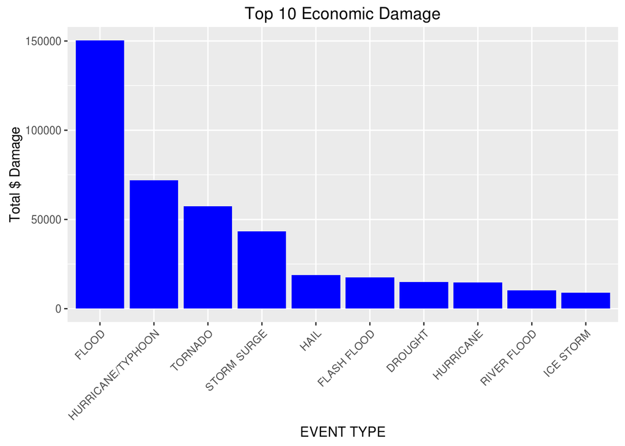

```r
# plot
Top10_economic_damage$EVTYPE <- factor(Top10_economic_damage$EVTYPE, levels = Top10_economic_damage$EVTYPE)
ggplot(Top10_economic_damage, aes(x = EVTYPE, y = TotalDmg)) +
  geom_bar(stat = "identity", fill = "blue") +
  theme(axis.text.x = element_text(angle = 45, hjust = 1)) +
  xlab("EVENT TYPE") + ylab("Total $ Damage") +
  ggtitle("Top 10 Economic Damage")
```